# R Notebook: First Practical 2023

In this practical you will be manipulating network data using the igraph package in R. Call R and change directory to the folder where you store your networks files. Once in the R environment please type, to make sure the package is installed

```r
# install.packages("igraph")
```

The igraph package documentation can be found at https://cran.r-project.org/web/packages/igraph/igraph.pdf

```r
library(igraph)
```

Part A: Network data visualisation and summaries

First we look at a data set of protein interactions in yeast. The yeast data are in the so-called .net format, which comes from another network package called Pajek. The .net format is supported by igraph. Remove self-loops and multiple edges, and then have a look at the data.

```r
yeast<-read.graph("http://www.stats.ox.ac.uk/~reinert/dtc/YeastL.net", format="pajek")
graph <-simplify(yeast, remove.multiple=TRUE, remove.loops=TRUE)
V(graph)$id
```

```
   [1] "ABD1 mRNA cap methyltransferase"
   [2] "RPB2 DNA-directed RNA polymerase II, 140 kDa chain"
   [3] "SPT5 transcription elongation protein"
   [4] "ACC1 acetyl-CoA carboxylase"
   [5] "YLR386w similarity to hypothetical S. pombe protein"
   [6] "SIT4 ser/thr protein phosphatase"
   [7] "CCT5 T-complex protein 1, epsilon subunit"
   [8] "ADE1 phosphoribosylamidoimidazole-succinocarboxamide synthase"
   [9] "ADE12 adenylosuccinate synthetase"
  [10] "ADE13 adenylosuccinate lyase"
  [11] "PRT1 translation initiation factor eIF3 subunit"
  [12] "ADE4 amidophosphoribosyltransferase"
  [13] "RNA1 GTPase activating protein"
  [14] "CYS3 cystathionine gamma-lyase"
  [15] "ADE5,7 phosphoribosylamine-glycine ligase and phosphoribosylformylglycinamidine cyclo-ligase"
```

[output cut: 986 more lines]

[figure not shown]

```r
plot(graph,vertex.label=V(graph)$name)
```

This plot is not so helpful but you can vary the plot parameters; for example

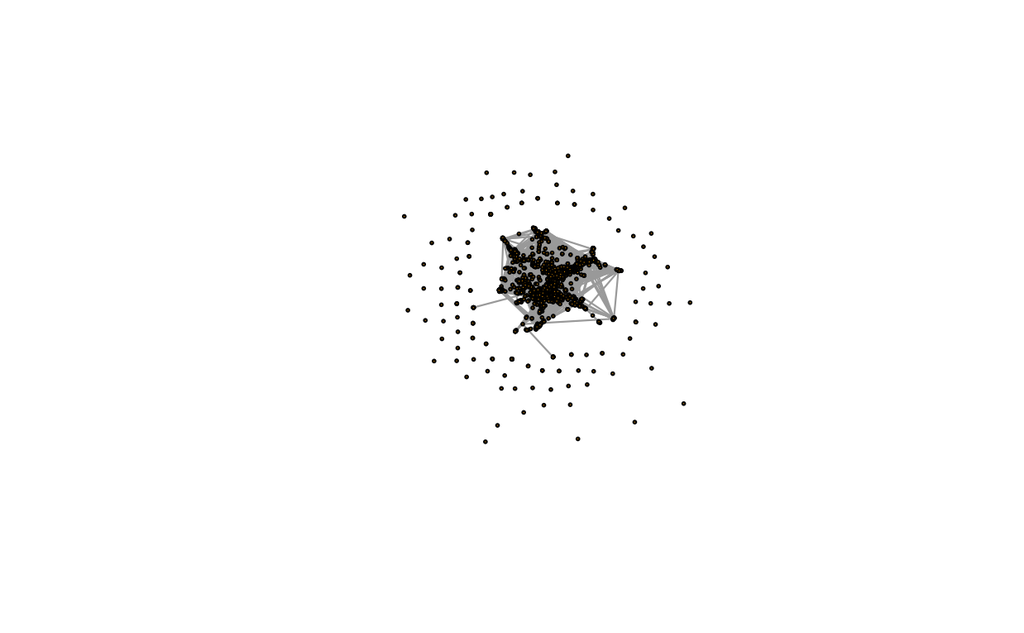

```r
plot(graph, layout=layout_nicely,vertex.label.dist=0, vertex.size=2, vertex.label="")
```

Look at some properties of the network:

```r
graph.density(graph, loops=FALSE)
```

```
[1] 0.002385516
```

```r
average.path.length(graph, directed=FALSE, unconnected=TRUE)
```

```
[1] 4.376182
```

```r
transitivity(graph, type=c("undirected"), vids=NULL)
```

```
[1] 0.1023149
```

```r
diameter(graph, directed = FALSE, unconnected = TRUE, weights = NULL)
```

```
[1] 11
```

The degrees of every vertex can also be reported; to find the average degree use

```r
summary(degree(graph))
```

```
   Min. 1st Qu.  Median    Mean 3rd Qu.    Max.
   0.00    1.00    3.00    5.63    7.00   64.00
```

For vertex betweenness:

```r
bet<-betweenness(graph, v=V(graph), directed = FALSE)
summary(bet)
```

```
   Min. 1st Qu.  Median    Mean 3rd Qu.    Max.
      0       0     163    3535    2902  105169
```

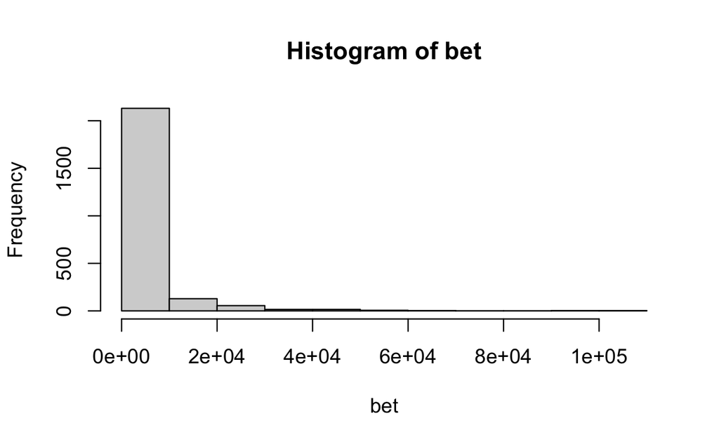

```r
hist(bet)
```

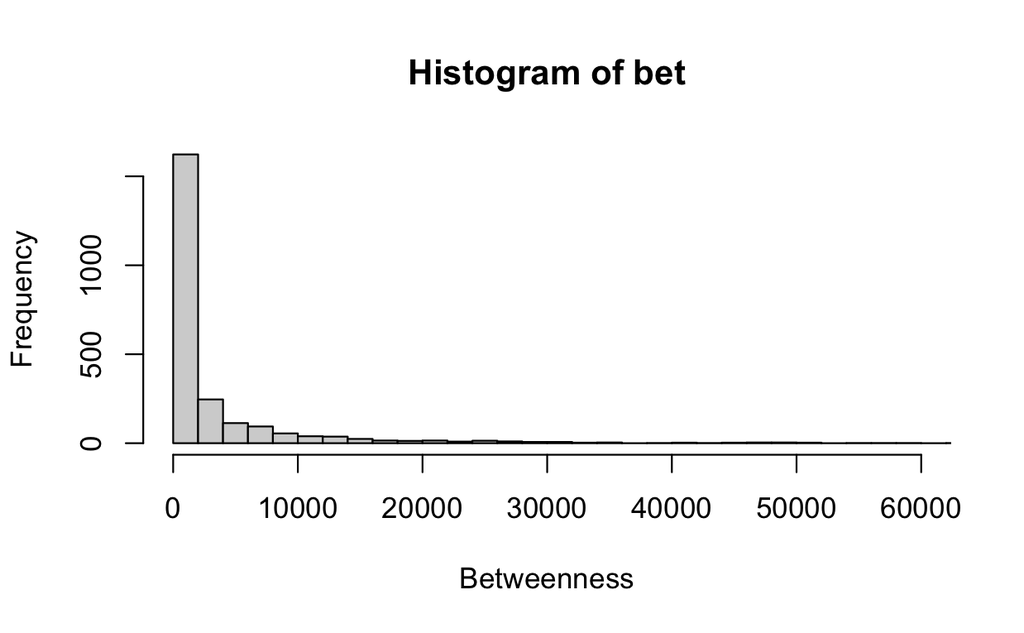

```r
hist(bet, breaks="Scott", xlab="Betweenness", xlim = c(0,6e+04))
```

The hist command also has other options; to find out more,

```r
?hist
```

There are a number of other network summaries which you could try out; have a look at the igraph package documentation.

Part B: Simulating networks

In the second part of this practical the aim is to simulate networks from some random network models. The igraph package makes it easy to simulate from different random graph models.

1 Erdös-Rényi graphs

To generate an Erdös-Rényi random graph with 10,000 vertices and edge probability 1/1000, or 2/1000, we can use

```r
er1<- sample_gnp(10000, 1/1000)
er2<- sample_gnp(10000, 2/1000)
```

We can compare their degree distributions, i.e. the vector which counts the number of vertices of degree 0, degree 1, and so on. In R the function par is used to control graphical parameters. To generate an array of two plots in the same display try

[figure not shown]

```r
par(mfrow=c(2,1))
hist(degree(er1))
hist(degree(er2))
```

You may also be interested in

```r
mean(degree(er1))
```

```
[1] 10.0066
```

```r
mean(degree(er2))
```

```
[1] 20.1062
```

Let’s look at their clustering coefficients; the default option is the global clustering coefficient:

```r
transitivity(er1, type="global")
```

```
[1] 0.0009582043
```

```r
transitivity(er2, type="global")
```

```
[1] 0.002038402
```

What would you have expected to see?

2. Watts-Strogatz small worlds

For a Watts-Strogatz network we have to specify the dimension of the lattice, the number of vertices, the size of the neighbourhood, and the rewiring probability. We can use the command

```r
ws1<-sample_smallworld(1, 100, 4, 0.1)
```

where 1 is the dimension, 100 is the number of vertices, 4 is the neighbourhood size, and 0.1 is the rewiring probability. Plot the network using

```r
plot(ws1, layout=layout.circle)
```

[output not shown]

Find the average degree, the clustering coefficient and the average shortest path. What happens if p=0.05?

3. Barabasi-Albert networks

```r
bar1<-sample_pa(100, directed=FALSE)
```

For a Barabasi-Albert network on 100 vertices with preferential attachment proportional to the square of the vertex degree, we can use

```r
bar2<-sample_pa(100, power=2, directed=FALSE)
```

Plot as a tree:

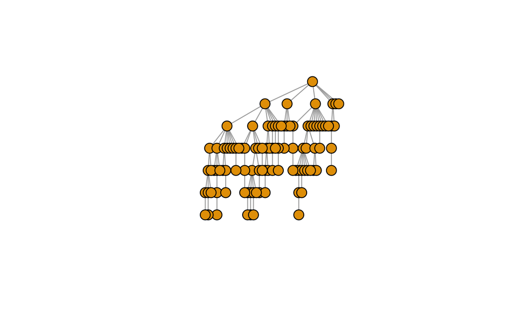

```r
plot(bar1, layout=layout_as_tree,vertex.label="")
```

Find the average degree, the clustering coefficient and the average shortest path length.

4. Configuration model

The sequence of degrees in the Florentine marriage network is 1, 3, 2, 3, 3, 1, 4, 1, 6, 1, 3, 0, 3, 2, 4, 3. Generate a network under the configuration model using this degree sequence:

```r
dflo<-c(1,3,2,3,3,1,4,1,6,1,3,0,3,2,4,3)
deggraph<-sample_degseq(dflo)
summary(deggraph)
```

```
IGRAPH 6f12646 U--- 16 20 -- Degree sequence random graph
+ attr: name (g/c), method (g/c)
```

If you want to make sure that the network is simple then you can use instead

```r
deggraph<- sample_degseq (dflo, method="simple.no.multiple")
```

Plot your simulated network. Is your simulated network connected?

You can use

```r
length(triangles(deggraph))
```

```
[1] 12
```

to count the number of triangles a vertex is part of. How do you obtain the number of triangles in the network? triangles(graph)

Compare this to the local clustering coefficient:

```r
transitivity(deggraph, type="local")
```

[output not shown]

## Problem Sheet 2:

2. Create a random graph G from a model of your choice, on 500 vertices, with parameter value of your choice, and calculate the global clustering coefficient. Repeat 100 times and make a histogram for the global clustering coefficients.

```r
vt <- numeric(100)
vd <- numeric(100)
vc <- numeric(100)

p = 0.002

for ( i in 1:100)
{g<- sample_gnp(500, p)
vt[i]<-transitivity(g, type="global")
vd[i] <- mean(degree(g))
vc[i] <- no.clusters(g)
}

par(mfrow = c(1,3))
hist(vt, main = paste("G( 500,",p,")"), xlab = "global clustering coefficient")
abline(v = mean(vt), col = "red", lty = 2, lwd = 2)
```

```r
hist(vd, main = paste("G( 500,",p,")"), xlab = "Mean Degree")
abline(v = mean(vd), col = "red", lty = 2, lwd = 2)
```

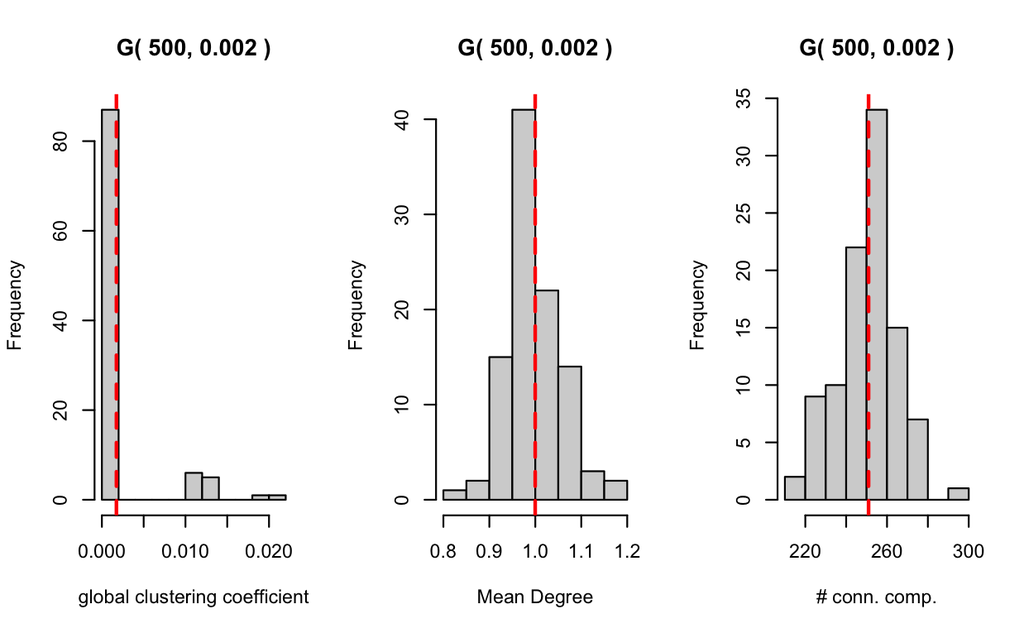

```r
hist(vc, main = paste("G( 500,",p,")"), xlab = "# conn. comp.")
abline(v = mean(vc), col = "red", lty = 2, lwd = 2)
```